# 可否根據停車場空位性質，區分種類？

### 利用自行搜集之橫斷面資料，透過非監督式機器學習探討停車場的種類

*台大經濟所 陳家威*

根據直覺，如「大安森林公園」之類的停車場，與位於西門町附近的「峨眉停車場」，本身因遊客性質不同，可以停的車為最多的時段以及標準差也會有不同。以下午休憩時光為主的「大安森林公園」，可預期週日下午車位會最少，而夜晚之後漸漸開始空出；相對的，西門町的停車場在晚上幾乎會是客滿的狀態。

我們是否能從這些性質出發，為停車場根據車位剩餘的時間與比例進行分類呢？

## 資料

此分析的資料來源是從2023年9月，到2023年12月所持續自動化搜集的資料。因為是透過台北市政府所提供的 API 每 5 分鐘進行搜席，因此主要涵蓋為台北市大部分之停車場。

存入資料庫的停車場資訊，再藉由以下 SQL 語法取得：

```
SELECT
    ps.parkid,
    ps.dow,
    ps.hr,
    AVG(ps.transqty) / pi2.numS AS mean,
    STD(ps.transqty) / pi2.numS AS std_dev,
    pi2.numS AS tot,
    pi2.parkname AS name
FROM parking_space ps
LEFT JOIN parking_info pi2 ON ps.parkid = pi2.parkid
GROUP BY ps.parkid, dow, hr
having tot>10;
```

以上語法計算出各個停車場根據各星期各小時分組計算平均值與標準差（以空位比例呈現）。將上面的資料下載後載入 python 當中進行分析：

```python
import pandas as pd
avg_weekly = pd.read_csv("/Users/ted/Agg_Weekly_park.csv")
```

```python
avg_weekly
```

|  | parkid | day_of_week | hour_of_day | mean | std_dev | tot | name |
| --- | --- | --- | --- | --- | --- | --- | --- |
| 0 | 1 | 1 | 0 | 0.421106 | 0.032556 | 2043 | 府前廣場地下停車場 |
| 1 | 1 | 1 | 1 | 0.424592 | 0.028223 | 2043 | 府前廣場地下停車場 |
| 2 | 1 | 1 | 2 | 0.431254 | 0.022614 | 2043 | 府前廣場地下停車場 |
| 3 | 1 | 1 | 3 | 0.435719 | 0.021331 | 2043 | 府前廣場地下停車場 |
| 4 | 1 | 1 | 4 | 0.437168 | 0.021646 | 2043 | 府前廣場地下停車場 |
| ... | ... | ... | ... | ... | ... | ... | ... |
| 76099 | 844 | 7 | 19 | 0.000000 | 0.000000 | 43 | 南港一停車場 |
| 76100 | 844 | 7 | 20 | 0.000000 | 0.000000 | 43 | 南港一停車場 |
| 76101 | 844 | 7 | 21 | 0.000000 | 0.000000 | 43 | 南港一停車場 |
| 76102 | 844 | 7 | 22 | 0.000000 | 0.000000 | 43 | 南港一停車場 |
| 76103 | 844 | 7 | 23 | 0.000000 | 0.000000 | 43 | 南港一停車場 |

76104 rows × 7 columns

為方便進行機器學習，我將各個時段的平均與標準差轉換為各停車場的特徵：

```python
pivot_table = pd.pivot_table(
    avg_weekly,
    values=['mean', 'std_dev'],
    index=['parkid', 'name'],
    columns=['day_of_week', 'hour_of_day'],
    fill_value=None
)

pivot_table
```

| parkid | day_of_week hour_of_day name | mean 1 0 | mean 1 | mean 1 2 | mean 1 3 | mean 1 4 | mean 1 5 | mean 1 6 | mean 1 7 | mean 1 8 | mean 1 9 | ... | std_dev 7 14 | std_dev 7 15 | std_dev 7 16 | std_dev 7 17 | std_dev 7 18 | std_dev 7 19 | std_dev 7 20 | std_dev 7 21 | std_dev 7 22 | std_dev 7 23 |
| --- | --- | --- | --- | --- | --- | --- | --- | --- | --- | --- | --- | --- | --- | --- | --- | --- | --- | --- | --- | --- | --- | --- |
| 1 | 府前廣場地下停車場 | 0.421106 | 0.424592 | 0.431254 | 0.435719 | 0.437168 | 0.437143 | 0.437451 | 0.434357 | 0.435869 | 0.435599 | ... | 0.084597 | 0.080629 | 0.080358 | 0.085321 | 0.087082 | 0.082692 | 0.083183 | 0.073328 | 0.050715 | 0.032881 |
| 2 | 松壽廣場地下停車場 | 0.759176 | 0.789066 | 0.823278 | 0.847070 | 0.868077 | 0.884634 | 0.887619 | 0.877473 | 0.862216 | 0.825586 | ... | 0.002054 | 0.002540 | 0.007033 | 0.016616 | 0.034007 | 0.024046 | 0.062292 | 0.099321 | 0.080670 | 0.042448 |
| 3 | 臺北市災害應變中心地下停車場 | 0.139969 | 0.134263 | 0.129508 | 0.124331 | 0.121478 | 0.123838 | 0.132678 | 0.120245 | 0.107883 | 0.079952 | ... | 0.031716 | 0.037882 | 0.026565 | 0.015224 | 0.013718 | 0.014450 | 0.038249 | 0.034337 | 0.034251 | 0.025750 |
| 5 | 立農公園地下停車場 | 0.158263 | 0.153653 | 0.152223 | 0.149977 | 0.148897 | 0.149218 | 0.152457 | 0.163953 | 0.170810 | 0.157592 | ... | 0.053645 | 0.068144 | 0.056192 | 0.053291 | 0.042687 | 0.044983 | 0.044725 | 0.039821 | 0.036238 | 0.037991 |
| 7 | 萬華國中地下停車場 | 0.072748 | 0.069376 | 0.064593 | 0.064272 | 0.065304 | 0.071601 | 0.072713 | 0.083826 | 0.094596 | 0.091981 | ... | 0.047514 | 0.043207 | 0.035581 | 0.040952 | 0.049147 | 0.039931 | 0.036365 | 0.033947 | 0.028808 | 0.026149 |
| ... | ... | ... | ... | ... | ... | ... | ... | ... | ... | ... | ... | ... | ... | ... | ... | ... | ... | ... | ... | ... | ... | ... |
| 839 | 林森台大站 | 0.000000 | 0.000000 | 0.000000 | 0.000000 | 0.000000 | 0.000000 | 0.000000 | 0.000000 | 0.000000 | 0.000000 | ... | 0.000000 | 0.000000 | 0.000000 | 0.000000 | 0.000000 | 0.000000 | 0.000000 | 0.000000 | 0.000000 | 0.000000 |
| 841 | 臺北市立明倫高級中學停車場 | 0.000000 | 0.000000 | 0.000000 | 0.000000 | 0.000000 | 0.000000 | 0.000000 | 0.000000 | 0.000000 | 0.000000 | ... | 0.000000 | 0.000000 | 0.000000 | 0.000000 | 0.000000 | 0.000000 | 0.000000 | 0.000000 | 0.000000 | 0.000000 |
| 842 | 弘盛開發股份有限公司停車場 | 0.000000 | 0.000000 | 0.000000 | 0.000000 | 0.000000 | 0.000000 | 0.000000 | 0.000000 | 0.000000 | 0.000000 | ... | 0.000000 | 0.000000 | 0.000000 | 0.000000 | 0.000000 | 0.000000 | 0.000000 | 0.000000 | 0.000000 | 0.000000 |
| 843 | 吉拾停車場台大尊賢場 | 0.372449 | 0.372236 | 0.372236 | 0.372449 | 0.372449 | 0.372449 | 0.372662 | 0.374787 | 0.368835 | 0.373937 | ... | 0.030039 | 0.059590 | 0.073072 | 0.067825 | 0.099040 | 0.101176 | 0.074218 | 0.060103 | 0.074097 | 0.077558 |
| 844 | 南港一停車場 | 0.000000 | 0.000000 | 0.000000 | 0.000000 | 0.000000 | 0.000000 | 0.000000 | 0.000000 | 0.000000 | 0.000000 | ... | 0.000000 | 0.000000 | 0.000000 | 0.000000 | 0.000000 | 0.000000 | 0.000000 | 0.000000 | 0.000000 | 0.000000 |

453 rows × 336 columns

```python
# 重新命名
pivot_table.columns = [f'w{col[1]}_h{col[2]}_t_{col[0]}' for col in pivot_table.columns]
df = pivot_table.reset_index()
```

這些蒐集到的資料有一個問題 --- 太多停車場沒有即時更新數據，或是根本沒有更新至台北市政府的資料平台，導致有些標準差都是 0，且車位數一直以來都固定。為了將這些誤差值移除，我根據欄位中有大量 0 的樣本移除：

```python
threshold = 20

zero_percentages = (df == 0).sum(axis=1) / df.shape[1] * 100
filtered_df = df[zero_percentages < threshold].reset_index(drop=True)
```

## 主成分分析 (PCA)

剩餘之停車場數量有 308 個，然而總計卻有 336 個欄位（不包含id 與名字）。另外，由於工作天（週一到週五）的個時段數值變化或許沒這麼大，許多欄位之間提供的資訊是相同的。總合以上兩點，最好先將資料透過主成分分析進行降維。

```python
from sklearn.decomposition import PCA

pca = PCA()
X  = filtered_df.iloc[:, 2:].values # 前兩欄分別是 id 與 name
pca.fit(X);
```

我們可以看看組成分分析之後，投影在新基底上的數值對整體的變異度貢獻多少：

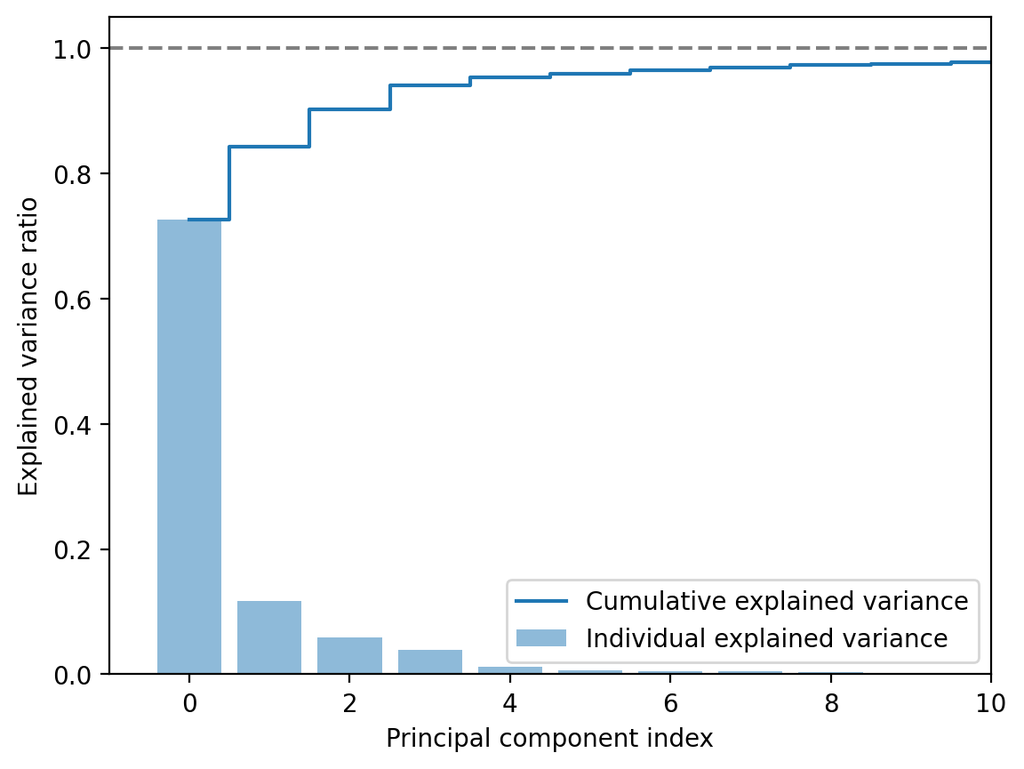

```python
import matplotlib.pyplot as plt
import numpy as np

plt.rcParams["figure.dpi"] = 200

X_after_pca = pca.fit_transform(X)
exp_var_pca = pca.explained_variance_ratio_
cum_exp_var = np.cumsum(exp_var_pca)

plt.bar(range(0,len(exp_var_pca)), exp_var_pca, alpha=0.5, align='center', label='Individual explained variance')
plt.step(range(0,len(cum_exp_var)), cum_exp_var, where='mid',label='Cumulative explained variance')
plt.hlines(1,-1,10,'grey', '--')
plt.xlim(-1,10)
plt.ylabel('Explained variance ratio')
plt.xlabel('Principal component index')
plt.legend();
```

可以觀察到，前兩個維度已經可以解釋 80% 以上的變異，而如果保留前 5 個維度，則可以解釋將近 96% 的變異度。因此，以下分析將保留前五個維度進行分析。

我們也可以將前兩個維度的資料畫出來觀察：

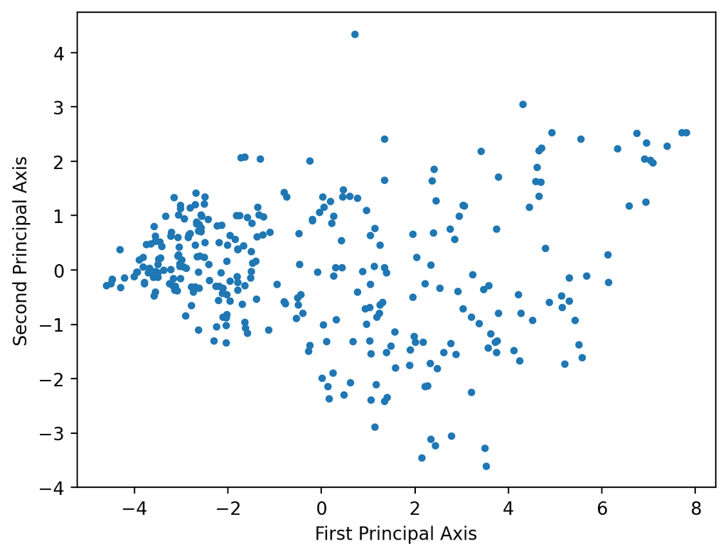

```python
plt.scatter(X_after_pca[:,0], X_after_pca[:,1], label = "Projected", s = 10)
plt.xlabel("First Principal Axis");
plt.ylabel("Second Principal Axis");
```

這是個相當棘手的分佈。位於散佈圖的左邊，依稀可以看見有一個密度較高的群聚，然而右邊則分散且似乎沒有一個特定的群聚出現。

## Density Based 分群法

由於出現密度上的群聚，且不清楚究竟可以分成多少類型，所以我首先會考慮 DBSCAN 或是 HDBSCAN 等等的演算法。這兩種分群法都是透過密度來分類，且不用特別指定要分成幾群，非常適合做為分析的第一步。

```python
import sklearn
import sklearn.cluster as cl
from sklearn.metrics import silhouette_score

X_after_pca = PCA(5).fit_transform(X)

methods = [
    cl.DBSCAN(eps= round(0.2 * k, 2)) for k in range(4, 20)
] + [cl.HDBSCAN()]


for i, classification in enumerate(methods):

    class_result = classification.fit_predict(X_after_pca)
    print(i, classification, silhouette_score(X, class_result), sep='\t\t')
```

```
0		DBSCAN(eps=0.8)		0.030908239724709574
1		DBSCAN(eps=1.0)		0.024005344458985566
2		DBSCAN(eps=1.2)		0.19847945551904503
3		DBSCAN(eps=1.4)		0.07086482219387516
4		DBSCAN(eps=1.6)		0.3022433195220288
5		DBSCAN(eps=1.8)		0.3908591420120785
6		DBSCAN(eps=2.0)		0.3908591420120785
7		DBSCAN(eps=2.2)		0.3908591420120785
8		DBSCAN(eps=2.4)		0.3908591420120785
9		DBSCAN(eps=2.6)		0.3908591420120785
10		DBSCAN(eps=2.8)		0.49431614265243934
11		DBSCAN(eps=3.0)		0.49431614265243934
12		DBSCAN(eps=3.2)		0.49431614265243934
13		DBSCAN(eps=3.4)		0.49431614265243934
14		DBSCAN(eps=3.6)		0.49431614265243934
15		DBSCAN(eps=3.8)		0.49431614265243934
16		HDBSCAN()		0.09261302832965683
```

在 $\varepsilon > 1.6$ 之後，衡量分群表現的 `silhouette_score`都超過了 0.39。看似有很好的表現，不過如果仔細看其中一筆（比方說當 $\varepsilon = 2.8$），可以發現其實他只分了一群，以及一個離群值：

```python
def plot_classification(index:int, method_list:list[sklearn.base.ClusterMixin], ax: plt.Axes = None, **kwargs):
    if ax is None:
        fig, ax = plt.subplots(1,1);
    else:
        fig = ax.get_figure();

    _lables = method_list[index].labels_
    for i in set(_lables):
        current_class_index = _lables == i
        ax.scatter(X_after_pca[current_class_index,0], X_after_pca[current_class_index,1], label = i, **kwargs);
    return fig
```

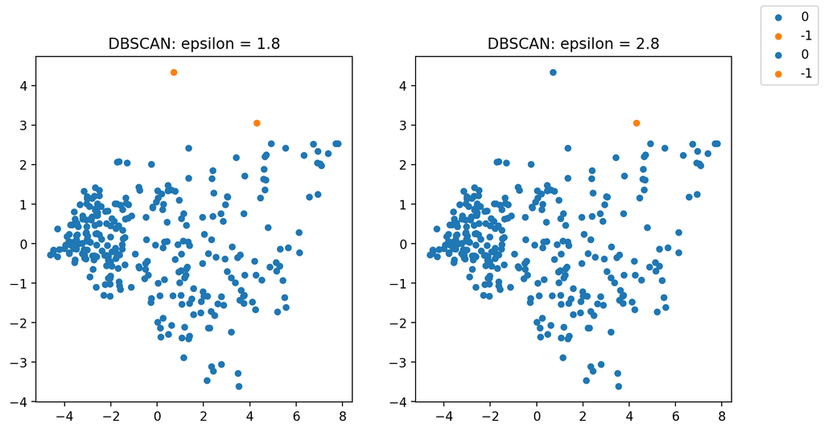

```python
fig, axs = plt.subplots(1,2, figsize=(10,5))

# e = 1.6
plot_classification(5, methods, s = 20, ax=axs[0]);
axs[0].set_title("DBSCAN: epsilon = 1.8");
# e = 2.8
plot_classification(10, methods, s = 20, ax=axs[1]);
axs[1].set_title("DBSCAN: epsilon = 2.8");
fig.legend();
```

而超參數很少的 HDBSCAN 的分群則非常混亂：

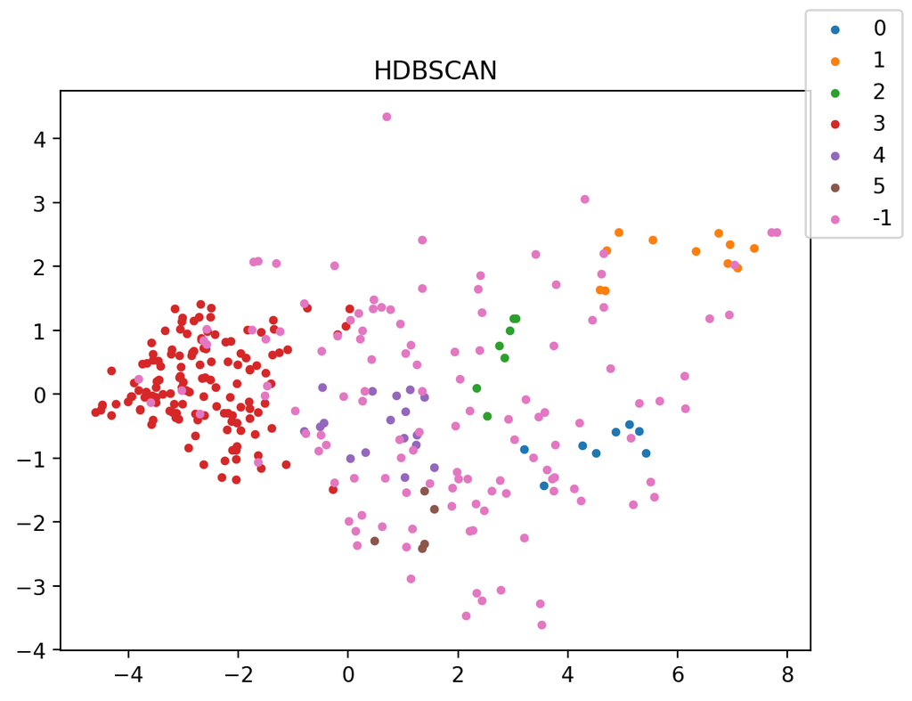

```python
fig = plot_classification(-1, methods, s = 10);
plt.title("HDBSCAN")
fig.legend();
```

上圖中，粉紅色表示被 HDBSCAN 分類為離群值。以主觀判斷來說，雖然左側密集的部分有被正確分類，但其他則沒有明顯的依據。我們可以回頭看看「大安森林公園」以及「峨眉停車場」，在 HDBSCAN 中，被歸類於哪一項

```python
filtered_df[(filtered_df.name.str.contains("大安森林公園", regex=False)) |
            (filtered_df.name.str.contains("峨眉", regex=False))]
```

|  | parkid | name | w1_h0_t_mean | w1_h1_t_mean | w1_h2_t_mean | w1_h3_t_mean | w1_h4_t_mean | w1_h5_t_mean | w1_h6_t_mean | w1_h7_t_mean | ... | w7_h14_t_std_dev | w7_h15_t_std_dev | w7_h16_t_std_dev | w7_h17_t_std_dev | w7_h18_t_std_dev | w7_h19_t_std_dev | w7_h20_t_std_dev | w7_h21_t_std_dev | w7_h22_t_std_dev | w7_h23_t_std_dev |
| --- | --- | --- | --- | --- | --- | --- | --- | --- | --- | --- | --- | --- | --- | --- | --- | --- | --- | --- | --- | --- | --- |
| 9 | 15 | 峨眉立體停車場 | 0.602972 | 0.687351 | 0.731729 | 0.754734 | 0.767604 | 0.773315 | 0.773878 | 0.776211 | ... | 0.003967 | 0.010019 | 0.028323 | 0.027535 | 0.012231 | 0.002326 | 0.015601 | 0.055169 | 0.088419 | 0.073061 |
| 44 | 56 | 大安森林公園地下停車場 | 0.276852 | 0.275976 | 0.275412 | 0.275333 | 0.274615 | 0.274232 | 0.268632 | 0.259637 | ... | 0.027648 | 0.025743 | 0.029795 | 0.042588 | 0.032717 | 0.031523 | 0.029337 | 0.020106 | 0.016430 | 0.015290 |

2 rows × 338 columns

```
-1 3
```

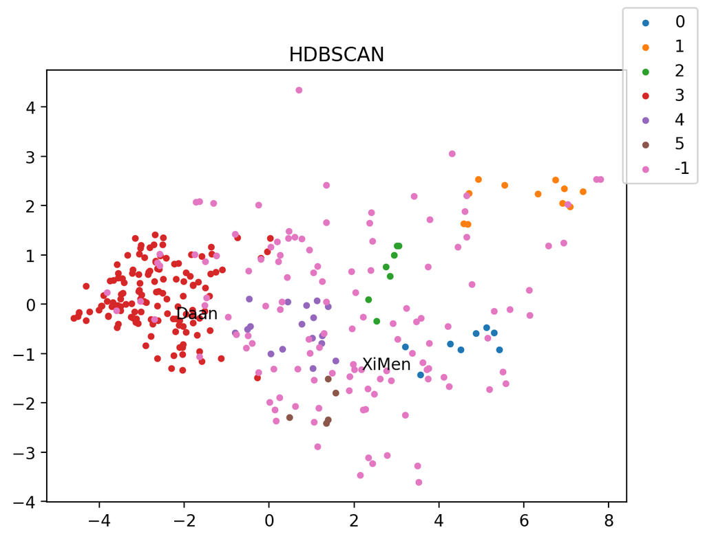

```python
print(methods[-1].labels_[9], methods[-1].labels_[44])
ax = fig.get_axes()[0]
ax.annotate("XiMen",(X_after_pca[9, 0],X_after_pca[9,1]));
ax.annotate("Daan", (X_after_pca[44, 0],X_after_pca[44,1]));
fig
```

大安森林公園被安排在紅色區域間，但同樣具有代表性的峨眉停車場，卻被視為離群值。

很顯然目前的資料，單靠密度為主的分類方式，沒辦法提供有用的分群。我接著嘗試看看傳統的 KMeans

## KMeans 分群法

由於沒有看似最佳的分群數量，因此一樣使用 silhouette score 來進行判斷。同時也可以用組內平方和(within-cluster sum of squares)，或稱inertia，來觀察，透過 Elbow method 來找尋較好的分類。

注意，KMeans 僅適用於當資料呈現 convex 的型態。如果有例如「環繞」型的分佈的話，KMeans 會給出不合理的結果。不果綜觀前面的資料，不太可能有這種情況。

```python
from sklearn.cluster import KMeans

kmean_methods = [KMeans(n_clusters=k, n_init='auto') for k in range(2,10)]

for i, method in enumerate(kmean_methods):

    class_result = method.fit_predict(X_after_pca)
    print(i, method, silhouette_score(X_after_pca, class_result), sep='\t')
```

```
0	KMeans(n_clusters=2, n_init='auto')	0.4887518770278574
1	KMeans(n_clusters=3, n_init='auto')	0.4188605079244328
2	KMeans(n_clusters=4, n_init='auto')	0.37022545642063287
3	KMeans(n_clusters=5, n_init='auto')	0.34914910570272634
4	KMeans(n_clusters=6, n_init='auto')	0.3001368802686542
5	KMeans(n_clusters=7, n_init='auto')	0.3243873161616326
6	KMeans(n_init='auto')	0.26306554757605705
7	KMeans(n_clusters=9, n_init='auto')	0.26314494388951676
```

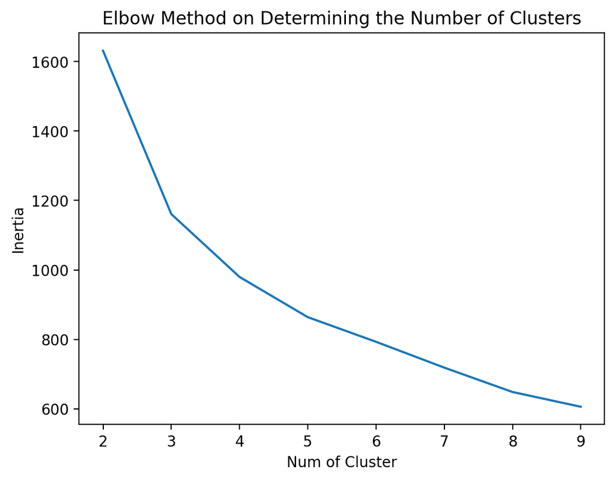

```python
inertias = [m.inertia_ for m in kmean_methods]
plt.plot(range(2,10), inertias);
plt.title("Elbow Method on Determining the Number of Clusters")
plt.xlabel("Num of Cluster");plt.ylabel("Inertia")
```

如果從 Silhouette score 的衡量方式來判斷，則分成兩群會是最好的。然而從 Elbow method 來看的話，$K=3$ 會是一個比較好的分群點。我們將 $K=2 \sim 5$ 畫出如下

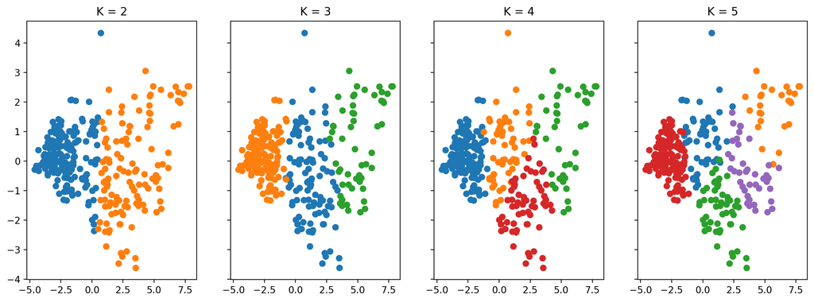

```python
fig_km, axs_km = plt.subplots(1,4, figsize=(15,5), sharey=True)

for k in range(4):
    plot_classification(k, kmean_methods, ax = axs_km[k]);
    axs_km[k].set_title(f"K = {k+2}")
```

# 結論

從以上分析來看，單就停車場不同時段上的空位性質來看，並不存在分群的必要。原因如下

1. 在經過主成份分析(PCA)之後，光前兩維就解釋了 80% 以上的數值變異度。而從這兩維所畫出的散佈圖觀察，可以看到並沒有很明顯的分群。為整體報告的整體性，我並沒有回報三圍的分佈，然而就算擴增一個維度，也依然無法分辨出有直覺的群聚。
2. 針對左邊密度較高的區域，我考慮了以密度作為分群依據的 DBSCAN 以及較彈性調整半徑的 HDBSCAN。前者未能分辨出左側的群聚與右側較鬆散的數據點，而後者則辨認出太多的離群值，實用性不大。
3. 透過較傳統的 KMeans 演算法，並搭配 Silhouette score 以及 Elbow method，也無法得到較為穩健的分類。Silhouette score 分數最高者為分兩群，然而 Elbow method 則建議分為三群。但整體表現依然比 DBSCAN 的結果滿意。

此次以各時段停車場的平均值以及標準差作為主要訓練的特徵。此分析結果告訴我們就目前台北市目前有提供資訊之停車場來看，停車場性質非常多元，需要更多觀察才能尋找適合的停車場，無法完全仰賴 data driven 的角度進行判斷，或是需要融合更多除了時段上的動差以外，更多描繪一個停車場的變數。